# mah_justin-13290085-week3

# 3. plot feature importance plot using XGBoost

The score based on how useful they are at predicting a target variable from the predictor variables based on their importance to predict the output.

[output not shown]

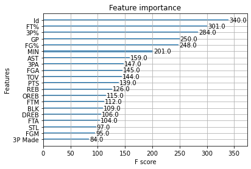

```python
# plot feature importance using built-in function
from xgboost import XGBClassifier
from xgboost import plot_importance
from matplotlib import pyplot


# fit model no training data
model = XGBClassifier()
model.fit(X, y)
# plot feature importance
plot_importance(model)
pyplot.show()
```

# 4. Permutation Feature Importance with KNN for Classification

source:https://machinelearningmastery.com/calculate-feature-importance-with-python/

If the decrease in quality is minimal, then the information in the predictor wasn’t very strong in determining your predictions, this mean the model is still pretty good without it.

Furthermore, if the decrease is large, then the information in the predictor had a large impact on your predictions.

source: https://towardsdatascience.com/from-scratch-permutation-feature-importance-for-ml-interpretability-b60f7d5d1fe9

## Permutation Feature Importance for Classification -KNN

This procedure breaks the relationship between the feature and the target, thus the drop in the model score is indicative of how much the model depends on the feature. This technique benefits from being model agnostic and can be calculated many times with different permutations of the feature.

```python
df = train.copy()
```

```python
target = df.pop('TARGET_5Yrs')
```

```python
X = df
y = target
```

```
Feature: 0, Score: 0.28278
Feature: 1, Score: 0.09881
Feature: 2, Score: 0.00259
Feature: 3, Score: 0.00005
Feature: 4, Score: -0.00048
Feature: 5, Score: -0.00008
Feature: 6, Score: 0.00159
Feature: 7, Score: -0.00018
Feature: 8, Score: -0.00027
Feature: 9, Score: 0.05732
Feature: 10, Score: -0.00022
Feature: 11, Score: -0.00023
Feature: 12, Score: 0.01384
Feature: 13, Score: -0.00006
Feature: 14, Score: -0.00008
Feature: 15, Score: 0.00004
Feature: 16, Score: 0.00009
Feature: 17, Score: -0.00010
Feature: 18, Score: -0.00004
Feature: 19, Score: -0.00044
```

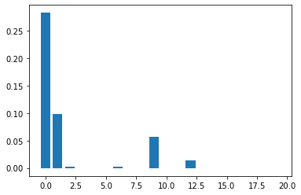

```python
# permutation feature importance with knn for classification
from sklearn.datasets import make_classification
from sklearn.neighbors import KNeighborsClassifier
from sklearn.inspection import permutation_importance
from matplotlib import pyplot
# define dataset

X_train, X_test, y_train, y_test = train_test_split(X, y, test_size=0.2, random_state=42)
# define the model
model = KNeighborsClassifier()
# fit the model
model.fit(X, y)
# perform permutation importance
results = permutation_importance(model, X, y, scoring='roc_auc')
# get importance
importance = results.importances_mean
# summarize feature importance
for i,v in enumerate(importance):
	print('Feature: %0d, Score: %.5f' % (i,v))
# plot feature importance
pyplot.bar([x for x in range(len(importance))], importance)
pyplot.show()
```

```python
# Feature selection for KNN
knn_fs1 = ['Id', 'GP', 'MIN','FG%','3P%','FT%']
knn_fs2 = ['Id', 'GP','3P%','FT%']
```

```python
# find feature number relating to which columns
for n in enumerate(X.columns):
    print(n)
```

```
(0, 'Id')
(1, 'GP')
(2, 'MIN')
(3, 'PTS')
(4, 'FGM')
(5, 'FGA')
(6, 'FG%')
(7, '3P Made')
(8, '3PA')
(9, '3P%')
(10, 'FTM')
(11, 'FTA')
(12, 'FT%')
(13, 'OREB')
(14, 'DREB')
(15, 'REB')
(16, 'AST')
(17, 'STL')
(18, 'BLK')
(19, 'TOV')
```

```python
# Create a copy of the train data and call it df
df = train.copy()

# Seperate the TARGETt_5YRS column from df and naming it as "target"
target = df.pop('TARGET_5Yrs')
```

```python
# Feature selection for KNN
knn_fs1 = ['Id', 'GP', 'MIN','FG%','3P%','FT%']
knn_fs2 = ['Id', 'GP','3P%','FT%']
```

## Apply the KNN permutation feature importance selected features

```python
# prepare the data

knn_train_select1 = df.loc[:,knn_fs1]
knn_train_select2 = df.loc[:,knn_fs2]
```

```python
# Allocating training and target data to X and y
X = df
y = target

# scaling the data predictors
scaler = StandardScaler()
# ksf1 = scaler.fit_transform(df)

knn_sel1 = scaler.fit_transform(knn_train_select1)
knn_sel2 = scaler.fit_transform(knn_train_select2)


# split into train-test sets
ksf1_X_train, ksf1_X_test, ksf1_y_train, ksf1_y_test = train_test_split(knn_sel1, y, test_size=0.2, random_state=42)

ksf2_X_train, ksf2_X_test, ksf2_y_train, ksf2_y_test = train_test_split(knn_sel2, y, test_size=0.2, random_state=42)

# knn
knn_clf1 = KNeighborsClassifier()
knn_clf2 = KNeighborsClassifier()

# model fit
knn_clf1.fit(ksf1_X_train, ksf1_y_train)
knn_clf2.fit(ksf2_X_train, ksf2_y_train)

# predict probabilities
knn_pred_prob1 = knn_clf1.predict_proba(ksf1_X_test)
knn_pred_prob2 = knn_clf2.predict_proba(ksf2_X_test)



# auc scores
knn_auc_score1 = roc_auc_score(ksf1_y_test, knn_pred_prob1[:,1])
knn_auc_score2 = roc_auc_score(ksf2_y_test, knn_pred_prob2[:,1])

print(f'The K Neighbours Classifier permutation feature importance ROC AUC score is {knn_auc_score1}')
print(f'The K Neighbours Classifier permutation feature importance ROC AUC score is {knn_auc_score2}')
```

```
The K Neighbours Classifier permutation feature importance ROC AUC score is 0.6142717792231062
The K Neighbours Classifier permutation feature importance ROC AUC score is 0.611085200110343
```

## Apply it to test data

```python
# make a copy of the test dataset as "test_data"
test_data =test.copy()

# prepare the permutation feature selection for test_data
knn_test_select1 = test_data.loc[:,knn_fs1]
knn_test_select2 = test_data.loc[:,knn_fs2]

# scaling the data predictors
scaler = StandardScaler()

knn_tsel1 = scaler.fit_transform(knn_test_select1)
knn_tsel2 = scaler.fit_transform(knn_test_select2)
```

```python
# Using knn_clf1 and knn_clf2 model to apply it to the test data selected features after standard scaling.
kfs1_pred_test = knn_clf1.predict_proba(knn_tsel1)

kfs2_pred_test = knn_clf2.predict_proba(knn_tsel2)
```

[output not shown]

```python
# Format the result to be submitted to Kaggle

# We want the Id column only
test.iloc[:,0]


# KNN SELECT FEATURE 1

#creating a dataframe combining test['Id'] and the results from the model for selected feature 1
ksf1_frames = [test.iloc[:,0], pd.DataFrame(kfs1_pred_test[:,1])]
knn_sf1_test_result = pd.concat(ksf1_frames, axis=1)

# re-labelling the columns
knn_sf1_test_result.columns = ['Id','TARGET_5Yrs']

knn_sf1_test_result["TARGET_5Yrs"] = knn_sf1_test_result["TARGET_5Yrs"].round(2)
knn_sf1_test_result



# KNN SELECT FEATURE 2

#creating a dataframe combining test['Id'] and the results from the model for selected feature 2
ksf2_frames = [test.iloc[:,0], pd.DataFrame(kfs2_pred_test[:,1])]
knn_sf2_test_result = pd.concat(ksf2_frames, axis=1)

# re-labelling the columns
knn_sf2_test_result.columns = ['Id','TARGET_5Yrs']

knn_sf2_test_result["TARGET_5Yrs"] = knn_sf2_test_result["TARGET_5Yrs"].round(2)
```

```python
knn_sf1_test_result
```

|  | Id | TARGET_5Yrs |
| --- | --- | --- |
| 0 | 1 | 0.8 |
| 1 | 8194 | 0.8 |
| 2 | 3 | 0.8 |
| 3 | 8196 | 1.0 |
| 4 | 8197 | 0.8 |
| ... | ... | ... |
| 3794 | 8175 | 1.0 |
| 3795 | 8176 | 1.0 |
| 3796 | 8178 | 0.6 |
| 3797 | 8181 | 0.8 |
| 3798 | 8183 | 0.8 |

3799 rows × 2 columns

```python
knn_sf2_test_result
```

|  | Id | TARGET_5Yrs |
| --- | --- | --- |
| 0 | 1 | 0.8 |
| 1 | 8194 | 0.6 |
| 2 | 3 | 1.0 |
| 3 | 8196 | 1.0 |
| 4 | 8197 | 0.8 |
| ... | ... | ... |
| 3794 | 8175 | 1.0 |
| 3795 | 8176 | 1.0 |
| 3796 | 8178 | 0.2 |
| 3797 | 8181 | 1.0 |
| 3798 | 8183 | 0.6 |

3799 rows × 2 columns

### Save the KNN permutation selected features to csv.

```python
# save to csv.

knn_sf1_test_result.to_csv("knn_permutation_sf1_test.csv",index=False)

knn_sf2_test_result.to_csv("knn_permutation_sf2_test.csv",index=False)
```

# 5. Feature Selection by "SelectFromModel" with Random Forest Classifier

Meta-transformer for selecting features based on importance weights.

The SelectFromModel is a meta-estimator that determines the weight importance by comparing to the given threshold value.

source: https://machinelearningmastery.com/calculate-feature-importance-with-python/

```python
# evaluation of a model using 5 features chosen with random forest importance
from sklearn.model_selection import train_test_split
from sklearn.feature_selection import SelectFromModel
from sklearn.ensemble import RandomForestClassifier
from sklearn.linear_model import LogisticRegression
from sklearn.metrics import accuracy_score

# feature selection
def select_features(X_train, y_train, X_test):
	# configure to select a subset of features
	fs = SelectFromModel(RandomForestClassifier(n_estimators=1000), max_features=10)
	# learn relationship from training data
	fs.fit(X_train, y_train)
	# transform train input data
	X_train_fs = fs.transform(X_train)
	# transform test input data
	X_test_fs = fs.transform(X_test)
	return X_train_fs, X_test_fs, fs



# split into train and test sets
X_train, X_test, y_train, y_test = train_test_split(X, y, test_size=0.2, random_state=42)

# feature selection
X_train_fs, X_test_fs, fs = select_features(X_train, y_train, X_test)

# fit the model
model = LogisticRegression(solver='liblinear')
model.fit(X_train_fs, y_train)


# evaluate the model
yhat = model.predict(X_test_fs)
# evaluate predictions
accuracy = accuracy_score(y_test, yhat)
auc_roc = roc_auc_score(y_test, yhat)
print('accuracy: %.2f' % (accuracy*100))
print('roc_auc score: %.2f' % (auc_roc*100))
```

```
accuracy: 83.50
roc_auc score: 50.12
```